# Tutorial

2026-03-17

## **UNBIASED ANALYSIS OF sc- and sp-RNASeq DATA IN SEURAT**

#### Tutorial written and maintained by Sergey Leikin, leikins@mail.nih.gov

Based on Cell Reports Methods manuscript (early preprint available at https://www.biorxiv.org/cgi/content/short/2025.10.20.683496v3) and R functions and files deposited at https://github.com/sergeyleikin/sc-sp-RNASeq.

Chapters and sections marked UNDER CONSTRUCTION have not been written yet. Please stay tuned for weekly/monthly updates.

**Requirements**  
Seurat v.5.4.0 and SeuratObject v.5.3.0 or later packages must be installed for the tutorial code to work. Earlier Seurat versions are incompatible with code for import and processing of Visium and VisiumHD data due to a change in the coordinate system implemented starting from Seurat 5.4.0.

Our method is designed for analysis scRNASeq data and spatial RNASeq based on full transcriptome sequencing (including Visium and similar assays). It is NOT designed for spatial data based on Xenium, Vizgen, and similar RNA imaging assays, analysis of which requires a different approach.

### TOC

**BASIC TUTORIAL** @ALL-USERS  
**Chapter 1. Single cell RNASeq**  
Section 1.0. Getting started  
Section 1.1. Cell identities and assay requirements  
Section 1.2. DGE.2Samples()  
Section 1.3. Understanding DGE.2Samples() output  
Section 1.4. Understanding DGE.2Samples() parameters  
Section 1.5. Seurat objects for multiple sample DGE analysis  
Section 1.6. Multiple sample DGE analysis with DGE.MultiSample()  
Section 1.7. Understanding DGE.MultiSample() output  
Section 1.8. DGE.MultiSample() parameters  
Section 1.9. 3-step multiple sample DGE analysis (recommended)  
**Chapter 2. Quality control and parameter optimization**  
Section 2.1. Optimizing 2-sample DGE analysis  
Section 2.2. Optimizing multiple sample DGE analysis  
**Chapter 3. Spatial RNASeq**  
Section 3.1. Low resolution assays (Visium)  
Section 3.2. High resolution assays (VisiumHD)  
**Chapter 4. Multiple comparison corrections**  
Section 4.1. Bonferroni adjustment  
Section 4.2. Benjamini-Hochberg FDR

**ADVANCED TUTORIAL** (UNDER CONSTRUCTION)  
**Chapter 5. Weighted t-test vs. non-weighted t-test**  
**Chapter 6. Advanced parameter optimization**  
**Chapter 7. Degrees of freedom in weighted t-test**

**PERSONAL THOUGHTS AND COMMENTS** (UNDER CONSTRUCTION)  
**Data analysis in physics vs. biology**  
**Occam’s razor, maximum entropy methods, and logical maxims**  
**Uses and abuses of generative AI in transcriptomic analysis**

## **BASIC TUTORIAL**

### **Chapter 1: Single cell RNASeq**

**Notice:** If you are an R expert, please do not expect professional or fully optimized R code. Instead, my goal is code that is easy to write and understand.This tutorial assumes that all needed files have been downloaded to C:/scRNASeq folder (R notations). Any folder can be used instead, in which case C:/scRNASeq in the code below must be replaced with the folder path.

#### Section 1.0. Getting started

Download Neuron.QC.rds and sc-spRNASeqFunctions_v2i.R files and run the following code (after replacing C:/scRNASeq with the path to the folder containing these files):

```r
library("Seurat")
source("C:/scRNASeq/sc_spRNASeqFunctions_v2i.R")
Neuron.QC=readRDS("C:/scRNASeq/Neuron.QC.rds")
```

This code loads Seurat library, functions encoded in sc-spRNASeqFunctions_v2i.R, and Neuron.QC Seurat object.

Neuron.QC contains raw scRNASeq counts of glutamatergic (active identity “GLUT”) and GABAergic neurons (active identity “GABA”)

**NOTICE:** Install missing packages and libraries as directed by warning messages.

#### Section 1.1. Cell identities and assay requirements

There are multiple approaches to separating cells within each scRNASeq dataset into groups (identities within Seurat) for DGE analysis. Please see Seurat instructions for approaches recommended by Seurat. In my opinion, however, the most reliable approach is based on marker genes. Please see the Cell Rep. Methods manuscript for discussion of different approaches.

**Step 1**: Normalize data using the Relative Counts (RC) normalization method. **Do not** use the Seurat’s default log-normalization (see the Cell Rep. Methods for explanation of artifacts introduced by log-normalization).

```r
Neuron.QCN=NormalizeData(Neuron.QC, normalization.method = "RC")
```

**Step 2**: Quality control (QC) based on fraction of mitochondrial transcripts, number of counts, number of features, etc (Neuron.QC is QC pre-processed).

**Step 3**: Subset cells based on relative expression of marker genes (the normalized expression threshold does not have to be zero).

```r
GABA.QC=subset(Neuron.QCN, subset = Gad1>0 & Gad2>0 & Slc6a1>0 & (Gls==0 | Grin2b==0 | Slc17a7==0))
GLUT.QC=subset(Neuron.QCN, subset = Gls>0 & Grin2b>0 & Slc17a7>0 & (Gad1==0 | Gad2==0 | Slc6a1==0))
```

**Step 4**: Remove normalized data layers and objects that are no longer needed and only increase memory demand and slow down analysis.

```r
GABA.QC[["RNA"]]$data<-NULL
GLUT.QC[["RNA"]]$data<-NULL
rm(Neuron.QCN)
```

Step 5: Set unique identities of the cells in GABA.QC and GLUT.QC and merge all cells into a single Seurat object (rebuilt Neuron.QC).

```r
Idents(GLUT.QC)="glutcells"
Idents(GABA.QC)="GABAcells"
Neuron.QC=JoinLayers(merge(GLUT.QC, y=GABA.QC))
```

**IMPORTANT:**

1. Always use the JoinLayers() function because our data analysis functions require a single counts layer.
2. The active assay must be “RNA” for our functions to work (see Seurat’s RenameAssays() function).
3. **Use only original raw counts** (see Cell Rep. Methods manuscript for explanation of artifacts introduced by preprocessing of counts with functions like SCTransform()).
4. SCTransform() creates a new “SCT” assay and makes it active while preserving the “RNA” assay. If your object has been SCT pre-processed, you can just make the “RNA” assay active and then remove the SCT assay (see Seurat instructions).

#### Section 1.2. DGE.2Samples()

The object Neuron.QC we just reassembled is ready for the analysis. The results of the analysis are produced by a single function

```r
DGE.results=DGE.2samples(Neuron.QC, ident.1 = "glutcells", ident.2 = "GABAcells")
```

This code performs DGE analysis between “glutcells” and “GABAcells” using default settings. You may encounter situations in which you may want to group several identities together and compare the groups. In the following mock example, we compare all Neuron.QC cells to themselves

```r
NULL.results=DGE.2samples(Neuron.QC, ident.1 = c("glutcells","GABAcells"), ident.2 = c("glutcells","GABAcells"))
```

```r
head(NULL.results)
```

```
##         log2FC p.value Counts/Cell.1 Counts/Cell.2 N.+_cells.1 N.+_cells.2
## Xkr4         0       1     0.3416206     0.3416206         526         526
## Gm19938      0       1     0.7900552     0.7900552         954         954
## Mrpl15       0       1     1.9972376     1.9972376        1634        1634
## Lypla1       0       1     0.2794659     0.2794659         452         452
## Tcea1        0       1     1.8549724     1.8549724        1565        1565
## Rgs20        0       1     0.1174033     0.1174033         166         166
##         Counts.1 Counts.2    Sum_w^2.1    Sum_w^2.2 Chi2.p.value
## Xkr4         742      742 0.0005122969 0.0005122969            1
## Gm19938     1716     1716 0.0005088562 0.0005088562            1
## Mrpl15      4338     4338 0.0006609380 0.0006609380            1
## Lypla1       607      607 0.0006046507 0.0006046507            1
## Tcea1       4029     4029 0.0006148918 0.0006148918            1
## Rgs20        255      255 0.0005287814 0.0005287814            1
```

You may combine as many identities as you wish, just keep in mind that it is not the best approach to multiple sample analysis. Before we discuss optional DGE.2samples() parameters and optimal settings, let’s discuss the analysis output.

#### Section 1.3. Understanding DGE.2Samples() output

Take a look at the structure of the DGE.result dataframe generated by the analysis.

```r
head(DGE.results)
```

```
##              log2FC      p.value Counts/Cell.1 Counts/Cell.2 N.+_cells.1
## Xkr4    -1.72746379 1.508410e-21     0.2910102     0.3915828         253
## Gm19938 -1.45819929 3.945424e-38     0.7284523     0.8508692         468
## Mrpl15   0.02186500 6.484253e-01     2.7849861     1.2195791         948
## Lypla1  -0.29875939 3.103853e-02     0.3595922     0.2003660         286
## Tcea1   -0.07754282 1.385491e-01     2.5329008     1.1857274         908
## Rgs20   -1.19603284 6.861898e-06     0.1158480     0.1189387          75
##         N.+_cells.2 Counts.1 Counts.2    Sum_w^2.1    Sum_w^2.2 Chi2.p.value
## Xkr4            273      314      428 0.0010917854 0.0009825243 2.985763e-55
## Gm19938         486      786      930 0.0010125781 0.0009997311 2.160678e-95
## Mrpl15          686     3005     1333 0.0011284367 0.0013078973 6.842078e-01
## Lypla1          166      388      219 0.0010613339 0.0012033431 8.107716e-03
## Tcea1           657     2733     1296 0.0010691492 0.0012339251 1.214113e-01
## Rgs20            91      125      130 0.0009651356 0.0011083073 9.063239e-12
```

The row names are the genes. Column name extensions .1 and .2 refer to ident.1 and ident.2, respectively. The following output values are reported:  
**log2FC** - logarithm base 2 of the ratio of the weighted mean relative counts in the two identities. log2FC=0 means no DGE. log2FC=1 means 2-fold upregulation of the gene in identity 1 vs. identity 2. log2FC=n means 2<sup>n</sup> -fold upregulation.  
**p.value** - DGE p-value (probability of the observed log2FC under the “null hypothesis” of the same gene expression in the two identities).  
**Chi2.p.value** - Chi squared test p-value, which is a quality control parameter useful for identifying sampling bias effects in two-sample tests (see the Cell Rep. Methods manuscript).  
**Counts/cell** - average number of gene counts per cell (used for quality control, Section 2.1).  
**N.+_cells** - number of cells expressing the gene (quality control).  
**Counts** - aggregate count of the gene in each identity (quality control).  
**Sum_w^2** - sum of cell weight squares in each identity (see Chapter 2).

**Please note that DGE.results reports only 13,070 genes out of 21,091 genes with detected counts. The “missing” genes have been filtered out as not meeting minimum expression or other requirements set by optional DGE.2samples() parameters discussed in the next section.**

#### Section 1.4. Understanding DGE.2samples() parameters

**features** - list of genes to be analyzed (default: features=NULL [all genes]), e.g., features=c(“A”,“B”,“C”) will cause analysis of genes A, B, and C.  
**fc.thr** - fold-change threshold filter (default: fc.thr=1 [no filter]), e.g., fc.thr=2 will cause analysis of just the genes with abs(log2FC)>1.  
**min.pct** - minimum fraction of cells that must express the gene in at least one of the two identities (default: min.pct=0, [no filter]).  
**min.count** - minimum aggregate count in at least one of the two identities (default: min.count=30).  
**sum.w2** - the value of Sum_w^2 above which weighted averaging switches to non-weighted one (default: sum.w2=0.4).  
**min.cells** - minimum number of cells in at least one of the identities for the gene to be analyzed and reported (default: min.cells=10).  
**icc** - method of calculating cell weights (default: icc=“i” [iterative weights]); other allowed settings are: icc=“A” - ANOVA-based weights, icc=1 - equal weights, and icc=0 - weights proportional to aggregate transcript counts per cell.  
**df.correction** (default: df.correction=FALSE), see ADVANCED TUTORIAL (df.correction=TRUE setting is allowed but not recommended).

#### Section 1.5. Seurat objects for multiple sample DGE analysis

The main pitfall of 2-sample analysis with DGE.2Samples() is that individual cells are not independent biological replicates in the context of studies of genotype and/or treatment effects. In the latter studies, 2-sample analysis may cause significant false positive findings. The traditional solution for this problem is the “pseudobulk” analysis of multiple (at least 3) samples per genotype/treatment. Multiple shortcomings of the traditional pseudobulk approach (including analysis bias) are discussed in the Cell Rep. Methods manuscript. Our solution is unbiased multiple sample analysis described below.

Our implementation of the multiple sample analysis requires all data being assembled into a single Seurat object. To demonstrate how to assemble a Seurat object meeting our requirements, in this section we create a mock multiple sample experiment and assemble the corresponding Seurat object. First, we randomly split the 1079 glutamatergic neurons in GLUT.QC into 3 mock biological replicates.

```r
set.seed(10)
glutcells=colnames(GLUT.QC[["RNA"]]$counts)
glutcells.r1=sample(glutcells,350)
glutcells.r2=sample(setdiff(glutcells,glutcells.r1),350)
glutcells.r3=setdiff(setdiff(glutcells,glutcells.r1),glutcells.r2)
Untr.r1=subset(GLUT.QC,cells=glutcells.r1)
Idents(Untr.r1)="untreated.1"
Untr.r2=subset(GLUT.QC,cells=glutcells.r2)
Idents(Untr.r2)="untreated.2"
Untr.r3=subset(GLUT.QC,cells=glutcells.r3)
Idents(Untr.r3)="untreated.3"
```

This code created 3 “untreated” biological replicates of glutamatergic neurons with distinct identities. Next we create 3 “treated” replicates by 50% upregulation of 100 randomly selected genes that have between 0.2 and 0.5 counts per cell.

**Step 1**: identifying genes with 0.2 to 0.5 counts per cell.

```r
GLUT.counts=as.matrix(GLUT.QC[["RNA"]]$counts)
GLUT.counts.02_05=GLUT.counts[(rowSums(GLUT.counts)/ncol(GLUT.counts)>0.2 & rowSums(GLUT.counts)/ncol(GLUT.counts)<0.5),]
genes=rownames(GLUT.counts.02_05)
```

**Step 2**: randomly selecting 100 of these genes.

```r
set.seed(10)
modgenes=sample(genes,100)
```

**Step 3**: generating “treated” samples.

```r
Tr.r1.mat=as.matrix(Untr.r1[["RNA"]]$counts)
Tr.r1.mat[modgenes,]=round(1.5*Tr.r1.mat[modgenes,])
Tr.r1=CreateSeuratObject(Tr.r1.mat)
Idents(Tr.r1)="treated.1"
Tr.r2.mat=as.matrix(Untr.r2[["RNA"]]$counts)
Tr.r2.mat[modgenes,]=round(1.5*Tr.r2.mat[modgenes,])
Tr.r2=CreateSeuratObject(Tr.r2.mat)
Idents(Tr.r2)="treated.2"
Tr.r3.mat=as.matrix(Untr.r3[["RNA"]]$counts)
Tr.r3.mat[modgenes,]=round(1.5*Tr.r3.mat[modgenes,])
Tr.r3=CreateSeuratObject(Tr.r3.mat)
Idents(Tr.r3)="treated.3"
```

We generated 6 Seurat objects for glutamatergic neurons from 6 mock experiments (3 “untreated” and 3 “treated”). Each group of glutamatergic neurons has a unique identity. We can now assemble a single Seurat object with 3 “untreated” replicates and 3 “treated” replicates that meets the requirements for our multiple sample analysis.

```r
GLUT.MS=JoinLayers(merge(Untr.r1, y=c(Untr.r2,Untr.r3,Tr.r1,Tr.r2,Tr.r3)))
```

Real multiple sample experiments should be assembled into a single Seurat object in the same way. As long as all relevant groups of cells have unique active identities, the Seurat object may contain hundreds or thousands of identities. The only requirement is that all cells within the same cell group (e.g., cell type) in a sample (i.e., biological replicate) have the same identity.

For instance, if we were to generate 3 untreated and 3 treated groups of GABAergic neurons, we would give unique identities to all of them and then assemble a single Seurat object with both glutamatergic and GABAergic neurons (6 samples, 2 identities per sample). This would enable us to compare treated and untreated glutamatergic neurons as well as treated and untreated GABAegric neurons. However, if we would want to compare treated and untreated glutamatergic+GABAergic neurons as a single group, we would need to change the identities of GABAergic neurons within each sample to match the corresponding identities of glutamatergic neurons (so that they are grouped together). Alternatively, one may use multiple identifiers for each cell in Seurat and set active identity to different identifiers depending on how one wants to group the cells (see Seurat instructions). The multiple sample DGE analysis is based on selecting relevant active identities from a single Seurat object.

#### Section 1.6. Multiple sample DGE analysis with DGE.MultiSample()

The simplest way to analyze multiple sample experiment is to use DGE.MultiSample() function with default parameters. However, this single-step approach is appropriate only when the number of samples per group is large enough (at least 5 or more). Otherwise, the analysis must be repeated with non-default parameters and a 3-step approach described in Section 1.9 becomes more convenient and faster. While our groups contain just 3 samples, we still start from the one-step approach to illustrate it.

```r
DGE.multi.results=DGE.MultiSample(GLUT.MS, samples.1 = c("untreated.1","untreated.2","untreated.3"), samples.2 = c("treated.1","treated.2","treated.3"))
```

Note that a list of identities in DGE.MultiSample() distinguishes different samples. In contrast, a list of identities in DGE.2Samples(), combines different cells within the same sample so that they are analyzed as a single group of cells. Therefore, cell identities may need to be renamed before using DGE.MultiSample() as we discussed above.

#### Section 1.7. Understanding DGE.MultiSample() output

The output of DGE.MultiSample() is not a dataframe like the one produced by DGE.2Samples() but a list containing 3 items: DGE dataframe, Sstats table, and parameter list

**Item 1:** DGE.multi.results$DGE is the dataframe of the analysis results.

```r
DGE.ms.results=DGE.multi.results$DGE
head(DGE.ms.results)
```

```
##              log2FC   p.value   Wtd.%UMI.1    Sd.%UMI.1 Av.cell.fr.1
## Xkr4    0.001541241 0.9918125 0.0011767783 8.143020e-05   0.23410227
## Gm19938 0.001572802 0.9788361 0.0030214402 8.251036e-05   0.43339867
## Mrpl15  0.001532665 0.9800824 0.0112557408 3.183377e-04   0.87851740
## Lypla1  0.001555591 0.9775548 0.0014428852 3.675673e-05   0.26538510
## Tcea1   0.001539832 0.9692660 0.0102315634 1.883742e-04   0.84173389
## Rgs20   0.001632658 0.9932532 0.0004132747 3.676610e-05   0.06946099
##         N.+_cells.1     Counts.1 Counts/cell.1 Sum_w^2.1   Wtd.%UMI.2
## Xkr4       88:71:94   108:88:118     0.2904485 0.3346409 0.0011755218
## Gm19938 145:154:169  237:258:291     0.7273652 0.3338184 0.0030181480
## Mrpl15  316:298:334 961:918:1126     2.7798492 0.3333740 0.0112437895
## Lypla1     97:93:96  128:125:135     0.3596859 0.3358269 0.0014413303
## Tcea1   297:295:316  852:917:964     2.5326071 0.3361473 0.0102206488
## Rgs20      21:27:27     39:48:38     0.1162784 0.3789667 0.0004128072
##            Sd.%UMI.2 Av.cell.fr.2 N.+_cells.2     Counts.2 Counts/cell.2
## Xkr4    8.134013e-05   0.23410227    88:71:94   108:88:118     0.2904485
## Gm19938 8.245235e-05   0.43339867 145:154:169  237:258:291     0.7273652
## Mrpl15  3.180065e-04   0.87851740 316:298:334 961:918:1126     2.7798492
## Lypla1  3.670988e-05   0.26538510    97:93:96  128:125:135     0.3596859
## Tcea1   1.881682e-04   0.84173389 297:295:316  852:917:964     2.5326071
## Rgs20   3.671603e-05   0.06946099    21:27:27     39:48:38     0.1162784
##         Sum_w^2.2
## Xkr4    0.3346404
## Gm19938 0.3338179
## Mrpl15  0.3333740
## Lypla1  0.3358262
## Tcea1   0.3361450
## Rgs20   0.3789519
```

**Item 2:** DGE.multi.results$Sstats is the statistics of the number of cells, total transcript counts, and average counts per cell in each sample.

```r
print(DGE.multi.results$Sstats)
```

```
##             untreated.1 untreated.2 untreated.3  treated.1  treated.2
## N.cells          350.00      350.00      379.00     350.00     350.00
## N.counts     8434033.00  8612704.00  9597839.00 8443106.00 8621833.00
## Counts/cell    24097.24    24607.73    25324.11   24123.16   24633.81
##              treated.3
## N.cells         379.00
## N.counts    9607920.00
## Counts/cell   25350.71
```

**Item 3:** DGE.multi.results$parameters is a list of the analysis parameters.

```r
print(as.data.frame(DGE.multi.results$parameters))
```

```
##               DGE.multi.results$parameters
## t.test                                   0
## min.pct                               0.03
## fc.thr                                   1
## max.pval                                 1
## min.cells                               10
## min.count                               10
## sum.w2                                 0.4
## df.correction                            0
```

**Evaluation of DGE.MultiSample() performance**

To understand what DGE.MUltiSample() analysis can and cannot do, we generate a smaller dataframe showing only the results with DGE p-values below 0.05.

```r
DGE.ms.p05=DGE.ms.results[DGE.ms.results$p.value<0.05,]
DE.genes=rownames(DGE.ms.p05)
DE.genes.check=length(intersect(DE.genes,modgenes))
print(paste0("Number of genes with p<0.05: ",length(DE.genes),"; Modified genes with p<0.05: ",DE.genes.check))
```

```
## [1] "Number of genes with p<0.05: 97; Modified genes with p<0.05: 97"
```

This dataframe contains 97 of the 100 genes we modified and no false positive findings.

The 3 “missing” genes have borderline-significant p-values because of very low counts (see Counts.1 in the output table below).

```r
m.genes=setdiff(modgenes,DE.genes)
head(DGE.ms.results[m.genes,])
```

```
##             log2FC    p.value   Wtd.%UMI.1    Sd.%UMI.1 Av.cell.fr.1
## Slc35e3 -0.9091664 0.05853217 0.0010322485 0.0001259279    0.2188541
## Blvrb   -0.8338551 0.07995493 0.0009278616 0.0001457733    0.1836939
## Dleu7   -0.8123163 0.12898185 0.0008155163 0.0001669243    0.1526197
##         N.+_cells.1  Counts.1 Counts/cell.1 Sum_w^2.1  Wtd.%UMI.2    Sd.%UMI.2
## Slc35e3    94:73:68 107:88:80     0.2560749 0.3341139 0.001938522 0.0002672023
## Blvrb      74:45:80  97:57:97     0.2319789 0.3337326 0.001653859 0.0002481769
## Dleu7      47:68:49 57:101:61     0.2041261 0.3351576 0.001432070 0.0002601300
##         Av.cell.fr.2 N.+_cells.2    Counts.2 Counts/cell.2 Sum_w^2.2
## Slc35e3    0.2188541    94:73:68 201:161:148     0.4749290 0.3339293
## Blvrb      0.1836939    74:45:80 171:104:177     0.4175776 0.3336170
## Dleu7      0.1526197    47:68:49 104:172:110     0.3596030 0.3350723
```

While this performance is not bad, the log2FC and p-values we calculated may not be accurate because the default parameters may not work well at 3 samples per treatment as discussed in Section 2.2.3.

**DGE.MultiSample() output columns**

**log2FC** - same as 2-sample analysis.  
**p.value** - same as 2-sample analysis.  
**Wtd%UMI** - gene expression averaged across biological replicates (% of UMI counts per cell).  
**Sd.%UMI** - standard deviation of Wtd%UMI.  
**Av.cell.fr** - fraction of cells expressing the gene averaged over biological replicates.  
**Counts/cell** - number of gene counts per cell averaged over replicates (quality control, Section 2.1).  
**N.+_cells** - number of cells expressing the gene in each sample, separated by “:” (quality control).  
**Counts** - aggregate count of the gene in each sample, separated by “:” (quality control).  
**Sum_w^2** - sum of sample weight squares, used for quality control (see Chapter 2).

Note that this dataframe is “missing” the Chi2.p.value column because the chi squared test is neither useful nor used for multiple sample analysis.

#### Section 1.8. DGE.MultiSample() parameters

DGE.MultiSample() has the following optional parameters that may be used for quality control and filtering of the results

**features** - same as in DGE.2samples (default: features=NULL [all genes]).  
**fc.thr** - same as in DGE.2samples (default: fc.thr=1 [no filter]).  
**min.pct** - similar to DGE.2samples, except this is the threshold for Av.cell.fr (default: min.pct=0.03 [Av.cell.fr>0.03]).  
**min.count** - same as in DGE.2samples, except summed over all samples (default: min.count=10). Does not filter results at default min.cells; may need to be increased at min.cells<10.  
**sum.w2** - similar to DGE.2samples, used for switching to non-weighted averaging of cells within each sample and switching to non-weighted sample averaging (default: sum.w2=0.4).  
**min.cells** - minimum number of cells in at least 3 samples within one of the two sample groups (default: min.cells=10).  
**icc** - method for calculating cell weights within each sample (default: icc=“i”), same as in DGE.2samples.  
**df.correction**- (default: df.correction=FALSE), see ADVANCED TUTORIAL.  
**t.test** - method for comparing sample groups (default: t.test=FALSE [weighted t-test used]; alternative: t.test=TRUE [non-weighted t-test used]).

#### Section 1.9. 3-step multiple sample DGE analysis

DGE.MultiSample() is a wrapper function for 3 analysis steps. It makes the analysis a bit simpler but requires more memory and may perform slowly for very large datasets (see Supp. Fig. S3 in our paper). Moreover, it is less convenient and slower for analysis of experiments with just 3-4 samples per genotype/treatment.

My preferred approach is going through the 3 analysis steps one by one in all cases. The parameters and output will be exactly the same, but parameter optimization will be a lot faster (seconds to minutes instead of hours for datasets with millions of cells). Moreover, the analysis will be better documented. These steps are illustrated below using the GLUT.MS Seurat object we created for the DGE.MultiSample() analysis.

**Step 1:** Weighted averaging of counts within each active identity of the Seurat object. Calculates weighted average counts, their variances and several other parameters.

**WARNING: Any renaming of identities, if needed, must be completed before running CntAv().**

```r
GLUT.MS=CntAv(GLUT.MS)
```

I recommend using the same Seurat object name for the output and CntAv() argument. In this case, CntAV() simply adds its output to the misc slot of the Seurat object instead of creating a new object. This step may take from seconds to hours, depending on the number of identities and cells in the Seurat object and on the power of the computer. I strongly recommend saving the resulting Seurat object, which can then be analyzed in many different ways with each analysis taking less than a minute on a good computer.

```r
saveRDS(GLUT.MS,"C:/scRNASeq/GLUT.MS.rds")
```

The only two parameters of the CntAv() function are **features** (genes to be analyzed) and **icc** (averaging method). At this step, I recommend averaging all genes (default). I recommend using the default icc=“i” for analyzing scRNASeq data and icc=0 for analyzing VisiumHD data (see Cell Rep. Methods manuscript). The value of icc defined in DGE.MultiSample() is used just for this first step.

**Step 2:** Assembly of sample matrix for further analysis. This is the step that defines which identities are used for the DGE analysis.

```r
GLUT.SampleMatrix=SampleMatrix(GLUT.MS,samples.1 = c("untreated.1","untreated.2","untreated.3"), samples.2 = c("treated.1","treated.2","treated.3"))
```

The only two parameters of SampleMatrix() are samples.1= and samples.2=. At least 3 identities are required for each of the two groups of samples. The Seurat object used by this function must be the one generated by CntAv() function.

**Step 3:** Analysis of DGE between the two sample groups in the sample matrix generated at Step 2.

```r
DGE.multi.results=WT.MultiSample(GLUT.SampleMatrix)
```

The WT.MultiSample() function has the same optional parameters as the DGE.MultiSample() function, except **icc** is not used at this step. The selection of genes for the analysis can be made at this step. The output produced by WT.MultiSample() is identical to the output of DGE.MultiSample() when the same analysis parameters are used.

**IMPORTANT:** DGE.MultiSample() is easier and may be useful only when: (a) Only one run of DGE analysis is anticipated with high degree of confidence, (b) The optimal analysis parameters are known a priori, and (c) There is zero likelihood of subsequent analysis adjustments or reevaluation of even some genes. In all other cases, the 3-step analysis saves a lot of time and headaches.

### **Chapter 2. Quality control and parameter optimization**

**Accuracy of any statistical analysis relies on having enough replicates and enough data points for each replicate.**

This Chapter provides basic recipes for balancing the analysis accuracy with practical realities of scRNASeq (high cost per sample, rare cell types, low expression genes that are important for the study). Main analysis parameters that can be adjusted to achieve the desired balance are: **min.pct**, **min.cells**, and **min.count** in 2-sample analysis plus **t.test** in multiple sample analysis. They define minimum thresholds for **Av.cell.fr**, **N.+_cells**, and **Counts**, respectively. I find nonzero **min.pct** setting to be useful only for multiple sample experiments, in which it ensures consistency between samples containing very different numbers of cells. Therefore, **Av.cell.fr** column is included only in the multiple sample analysis output, while **N.+_cells** and **Counts** are reported as quality control parameters for both multiple and 2-sample analyses. The **t.test** setting allows switching between weighted and non-weighted averaging of samples, which is essential in experiments with too few samples for reliable weighted averaging.

Additional settings that may affect/improve the balance between the analysis accuracy and data limitations are **icc** and **sum.w2**, although adjustments in **sum.w2** require more advanced understanding of the theory behind our analysis (see ADVANCED TUTORIAL).

#### Section 2.1. Optimizing 2-sample DGE analysis

**Increasing analysis accuracy**

Better accuracy can be achieved without changing the analysis parameters by *post hoc* elimination of genes with low counts and/or genes expressed in too few cells. Specifically, I recommend performing the analysis at default settings followed by filtering the results based on the values of **N.+_cells** and **Counts**. The statistical inference for genes with larger **N.+_cells** and **Counts** is more accurate, yet the additional accuracy benefit rapidly decreases at **N.+_cells** > 30-50 and **Counts** > 100.

**Enabling identification of important low expression genes**

The drawback of default analysis is that it may miss important low expression genes because they do not meet minimum expression requirements set by the default values of **min.cells** and **min.count**. To include such genes into the analysis, one may set **min.cells=3** and **min.count=0**. At **min.cells** and **min.count** settings below the default values, both iterative and ANOVA methods for calculation of the intracluster correlation coefficient **icc** become unreliable, necessitating analysis of the full range of possible icc values. Because icc varies between 0 and 1, I recommend running the analysis twice, once with icc=0 and once with icc=1 and follow the procedure described in the example below. For this analysis, I recommend using IterWghtTest() rather than the DGE.2Samples() function. The only difference between these two functions is that IterWghtTest() does not perform the chi squared test after the weighted t-test. At low counts, the chi squared test is unreliable, DGE.2Samples() would produce multiple warnings about that, and the reported chi squared test values would be useless anyway (DGE.2Samples() is a wrapper for two separate functions: IterWghtTest() and Chi2Test()).

```r
DGE.results.mc3=IterWghtTtest(Neuron.QC, ident.1 = "glutcells", ident.2 = "GABAcells", min.cells=3, min.count = 0, icc = 0)
DGE.results.mc3.icc1=IterWghtTtest(Neuron.QC, ident.1 = "glutcells", ident.2 = "GABAcells", min.cells=3, min.count = 0, icc=1)
```

Compared to DGE.2Samples() with default parameters, results of this analysis include over 4,000 additional lower expression genes

```r
low.exp.genes=setdiff(rownames(DGE.results.mc3),rownames(DGE.results))
print(length(low.exp.genes))
```

```
## [1] 4348
```

The results just for these genes are.

```r
DGE.results.mc3.LE=DGE.results.mc3[low.exp.genes,]
DGE.results.mc3.icc1.LE=DGE.results.mc3.icc1[low.exp.genes,]
```

Because the accurate calculation of icc for these genes is impossible, we can trust only those findings that are unaffected or just weakly affected by the icc value. Such findings should have similar values of log2FC at icc=0 and icc=1. For instance, we can select the genes with the difference in log2FC between icc=0 and icc=1 that is less than 0.3:

```r
DGE.results.LE=DGE.results.mc3.icc1.LE[(abs(DGE.results.mc3.icc1.LE$log2FC)==Inf&abs(DGE.results.mc3.LE$log2FC)==Inf)|(abs(DGE.results.mc3.icc1.LE$log2FC-DGE.results.mc3.LE$log2FC)<0.3),]
print(nrow(DGE.results.LE))
```

```
## [1] 2370
```

Here we selected the results from the DGE.results.mc3.icc1.LE dataframe to err on the side of caution (using more conservative statistical test with icc=1). Among the selected low expression genes

```r
DGE.results.LE.majorDGE=DGE.results.LE[(DGE.results.LE$p.value<0.0001)&(abs(DGE.results.LE$log2FC)>2),]
print(nrow(DGE.results.LE.majorDGE))
```

```
## [1] 20
```

20 have p<0.0001 and are up- or downregulated more than 4-fold.

The default analysis missed all these genes because of more stringent accuracy requirements. The DGE in these genes may be real or may be an artifact of insufficient transcript sampling (too few cells and too few counts). Depending on questions being addressed by experiments, one may want to at least know about such genes and maybe select some for validation by additional experiments (based not only on log2FC and p-values but also on **N.+_cells** and **Counts** values).

```r
knitr::kable(DGE.results.LE.majorDGE, digits = 5)
```

|  | log2FC | p.value | Counts/Cell.1 | Counts/Cell.2 | N.+_cells.1 | N.+_cells.2 | Counts.1 | Counts.2 | Sum_w^2.1 | Sum_w^2.2 |
| --- | --- | --- | --- | --- | --- | --- | --- | --- | --- | --- |
| Gm28723 | -4.80462 | 0e+00 | 0.00185 | 0.02562 | 2 | 28 | 2 | 28 | 0.00093 | 0.00091 |
| Meig1 | Inf | 4e-05 | 0.02132 | 0.00000 | 19 | 0 | 23 | 0 | 0.00093 | 0.00091 |
| Gm3279 | 3.92679 | 1e-04 | 0.02039 | 0.00091 | 22 | 1 | 22 | 1 | 0.00093 | 0.00091 |
| Adamtsl3 | Inf | 4e-05 | 0.02688 | 0.00000 | 24 | 0 | 29 | 0 | 0.00093 | 0.00091 |
| Gm32122 | Inf | 0e+00 | 0.02410 | 0.00000 | 26 | 0 | 26 | 0 | 0.00093 | 0.00091 |
| Gm15655 | -Inf | 3e-05 | 0.00000 | 0.02379 | 0 | 24 | 0 | 26 | 0.00093 | 0.00091 |
| Stra6 | Inf | 9e-05 | 0.01576 | 0.00000 | 17 | 0 | 17 | 0 | 0.00093 | 0.00091 |
| Vgll2 | Inf | 5e-05 | 0.01854 | 0.00000 | 18 | 0 | 20 | 0 | 0.00093 | 0.00091 |
| Otogl | Inf | 8e-05 | 0.01668 | 0.00000 | 17 | 0 | 18 | 0 | 0.00093 | 0.00091 |
| Caps2 | -5.43966 | 0e+00 | 0.00093 | 0.02653 | 1 | 29 | 1 | 29 | 0.00093 | 0.00091 |
| Hbq1b | Inf | 1e-05 | 0.02224 | 0.00000 | 22 | 0 | 24 | 0 | 0.00093 | 0.00091 |
| Rab11fip4os1 | Inf | 1e-05 | 0.01946 | 0.00000 | 21 | 0 | 21 | 0 | 0.00093 | 0.00091 |
| Spata20 | Inf | 2e-05 | 0.01854 | 0.00000 | 20 | 0 | 20 | 0 | 0.00093 | 0.00091 |
| Sphk1 | Inf | 5e-05 | 0.02039 | 0.00000 | 20 | 0 | 22 | 0 | 0.00093 | 0.00091 |
| Gm15902 | Inf | 0e+00 | 0.02688 | 0.00000 | 24 | 0 | 29 | 0 | 0.00093 | 0.00091 |
| Gm20063 | Inf | 4e-05 | 0.02132 | 0.00000 | 19 | 0 | 23 | 0 | 0.00093 | 0.00091 |
| Ocln | Inf | 4e-05 | 0.01761 | 0.00000 | 19 | 0 | 19 | 0 | 0.00093 | 0.00091 |
| Il3ra | Inf | 2e-05 | 0.02317 | 0.00000 | 22 | 0 | 25 | 0 | 0.00093 | 0.00091 |
| Gm49542 | 3.90121 | 1e-05 | 0.02688 | 0.00183 | 28 | 2 | 29 | 2 | 0.00093 | 0.00091 |
| Iigp1 | -Inf | 5e-05 | 0.00000 | 0.01830 | 0 | 20 | 0 | 20 | 0.00093 | 0.00091 |

#### Section 2.2. Optimizing multiple sample DGE analysis

While the idea behind optimizing multiple sample analysis parameters is similar, there are several important distinctions. Here, the parameters that can be optimized to achieve study objectives are **min.pct**, **min.cells**, **t.test**, and **icc**.

**2.2.1: Default min.pct setting**

The default **min.pct=0.03** setting ensures that at least 3% of all cells across all samples in one of the two groups express the gene. This is different from requiring that at least 3 samples in one of the two sample groups have **> min.cells** cells expressing the gene. The **min.pct** setting is therefore meaningful and should be used. The specific value for this setting depends on the goals and specific details of the study. A general recommendation may be counterproductive.

**2.2.2: Default min.count setting**

The default **min.count=10** setting has no effect on analysis at **min.cells > 3** because (3 x **min.cells > 3**) > 10. At default **min.cells=10**, at least one of the two sample groups will have at least 3 x 10 = 30 counts. This parameter is provided mostly for compatibility with DGE.2samples() function, enabling one to compare multiple sample and 2-sample analysis of the same data with the same parameters (An exercise I recommend to see pitfalls of 2-sample analysis when data are available from multiple samples). Optimization of this parameter is not a productive use of one’s time.

**2.2.3: Experiments with fewer than 5 samples per genotype/treatment (t.test setting)**

The default **t.test=FALSE** setting is optimal for many (at least 5 or more) samples per genotype or treatment when each sample contains many (>10-30) cells expressing genes of interest. The other, **t.test=TRUE** setting is optimal when the number of samples per group is small (3-4) and all samples have about the same number of cells. The reality is often between these two limits. When that is the case, it is worthwhile to perform analysis with both settings. Similar results for both settings are most reliable. Different results indicate that one of the tests is not accurate. In that case, I recommend erring on the side of caution and choosing the more conservative results, which still need to be validated.

For instance, we analyzed GLUT.MS with default parameters by using DGE.MultiSample() in Section 1.6 and the 3-step approach in Section 1.9. Because GLUT.MS was a mock experiment with just 3 samples per treatment, the results of such analysis might not be sufficiently accurate. At such small number of samples, it is important to repeat the analysis with t.test=TRUE.

```r
DGE.multi.results.t=WT.MultiSample(GLUT.SampleMatrix, t.test = TRUE)
```

```r
DGE.ms.results.t=DGE.multi.results.t$DGE
DGE.mst.p05=DGE.ms.results.t[DGE.ms.results.t$p.value<0.05,]
DE.genes=rownames(DGE.mst.p05)
DE.genes.check=length(intersect(DE.genes,modgenes))
print(paste0("Number of genes with p<0.05: ",length(DE.genes),"; Modified genes with p<0.05: ",DE.genes.check))
```

```
## [1] "Number of genes with p<0.05: 96; Modified genes with p<0.05: 96"
```

This analysis recovered 96 rather than 97 from the 100 modified genes because the non-weighted t-test may be too conservative (see the Cell Rep. Methods manuscript). However, unless additional validation experiments are planned, it may be better to err on the side of caution and select the more conservative findings from the analysis runs with t.test=FALSE and t.test=TRUE. For instance, the following table compare log2FC and p-values for t.test=FALSE and t.test=TRUE

```r
DGE.genes=rownames(DGE.ms.p05)
DGE.ms.res=cbind(DGE.ms.p05[DGE.genes,c(1:2)],DGE.mst.p05[DGE.genes,c(1:2)])
head(DGE.ms.res)
```

```
##              log2FC      p.value     log2FC      p.value
## Plcl1    -0.8962612 2.169275e-03 -0.8771548 2.660664e-03
## Skida1   -0.8649678 4.502768e-03 -0.8647097 4.854813e-03
## Sec16a   -0.8325940 3.681621e-03 -0.8307168 4.014467e-03
## Slc39a13 -0.9052349 3.476194e-02 -0.9077325 3.595299e-02
## Ino80    -0.8632481 1.140683e-02 -0.8600115 1.125741e-02
## Ninl     -0.8591572 6.512645e-07 -0.8594411 5.393723e-07
```

The first two columns are for t.test=FALSE and the next two are for t.test=TRUE. Among the 6 genes shown, 4 have larger p-values at t.test=TRUE and 2 at t.test=FALSE. While in our example the results are very close, this may not always be the case.

**2.2.4: Identifying DGE in low expression genes by utilizing non-default icc and min.cells settings**

The defaullt **icc=“i”** setting is optimal for genes with moderate to high expression (Counts/cell>0.1) detected in many cells (>10-30 cells per sample). The **icc=1** setting is not useful for multiple sample analysis. The “icc=0” setting is optimal for very low expression genes (Counts/cell<0.05-0.1). With this in mind I recommend running CntAv() once with default icc=“i” and once with icc=0 followed by the analysis illustrated below.

To illustrate analysis of low expression genes, let’s assemble a new mock multiple sample experiment, in which we modify 100 randomly selected genes with Counts/cell < 0.3 and total counts per sample group > 20

```r
GLUT.counts.under01=GLUT.counts[(rowSums(GLUT.counts)/ncol(GLUT.counts)<0.3&rowSums(GLUT.counts)>20),]
genes=rownames(GLUT.counts.under01)
set.seed(1)
modgenes=sample(genes,100)
Tr.r1.mat=as.matrix(Untr.r1[["RNA"]]$counts)
Tr.r1.mat[modgenes,]=round(2*Tr.r1.mat[modgenes,])
Tr.r1=CreateSeuratObject(Tr.r1.mat)
Idents(Tr.r1)="treated.1"
Tr.r2.mat=as.matrix(Untr.r2[["RNA"]]$counts)
Tr.r2.mat[modgenes,]=round(2*Tr.r2.mat[modgenes,])
Tr.r2=CreateSeuratObject(Tr.r2.mat)
Idents(Tr.r2)="treated.2"
Tr.r3.mat=as.matrix(Untr.r3[["RNA"]]$counts)
Tr.r3.mat[modgenes,]=round(2*Tr.r3.mat[modgenes,])
Tr.r3=CreateSeuratObject(Tr.r3.mat)
Idents(Tr.r3)="treated.3"
GLUT.MS=JoinLayers(merge(Untr.r1, y=c(Untr.r2,Untr.r3,Tr.r1,Tr.r2,Tr.r3)))
```

Default CntAv()/SampleMatrix()/WT.MultiSample() analysis

```r
GLUT.MS.i=CntAv(GLUT.MS, features = modgenes)
GLUT.SampleMatrix=SampleMatrix(GLUT.MS.i,samples.1 = c("untreated.1","untreated.2","untreated.3"), samples.2 = c("treated.1","treated.2","treated.3"))
DGE.multi.results=WT.MultiSample(GLUT.SampleMatrix)
DGE.ms.results=DGE.multi.results$DGE
DGE.ms.p05=DGE.ms.results[DGE.ms.results$p.value<0.05,]
```

```r
print(paste0("Genes with p<0.05 ",nrow(DGE.ms.p05),"; Modified genes included in the analysis: ",nrow(DGE.ms.results), sep = ","))
```

```
## [1] "Genes with p<0.05 55; Modified genes included in the analysis: 69,"
```

finds just 55 of the 100 modified genes, partly because 31 of the 100 modified genes have been excluded by default minimum expression requirements.

To identify lower expression genes, we can reanalyze them with min.pct=0 and min.cells=3, using more conservative t.test=TRUE.

```r
GLUT.MS.0=CntAv(GLUT.MS, features = modgenes, icc = 0)
GLUT.SampleMatrix.0=SampleMatrix(GLUT.MS.0,samples.1 = c("untreated.1","untreated.2","untreated.3"), samples.2 = c("treated.1","treated.2","treated.3"))
DGE.multi.results.0=WT.MultiSample(GLUT.SampleMatrix, t.test=TRUE, min.pct=0, min.cells=3)
DGE.ms.results.0=DGE.multi.results.0$DGE
```

After merging the default analysis results for genes with Counts/cell>=0.1 with the second analysis results for genes with Counts/cell<0.1,

```r
DGE.ms.results.filt=DGE.ms.results[(DGE.ms.results$`Counts/cell.1`>=0.1|DGE.ms.results$`Counts/cell.2`>=0.1),]
DGE.ms.results.filt.0=DGE.ms.results.0[(DGE.ms.results.0$`Counts/cell.1`<0.1&DGE.ms.results.0$`Counts/cell.2`<0.1),]
DGE.ms.results.comb=rbind(DGE.ms.results.filt,DGE.ms.results.filt.0)
DGE.ms.results.comb.p05=DGE.ms.results.comb[DGE.ms.results.comb$p.value<0.05,]
print(paste0("Genes with p<0.05: ",nrow(DGE.ms.results.comb.p05),"; Detected modified genes: ",nrow(DGE.ms.results.comb)))
```

```
## [1] "Genes with p<0.05: 63; Detected modified genes: 97"
```

```r
DGE.ms.results.comb.p01=DGE.ms.results.comb[DGE.ms.results.comb$p.value<0.1,]
print(paste0("Genes with p<0.1: ",nrow(DGE.ms.results.comb.p01)))
```

```
## [1] "Genes with p<0.1: 75"
```

we find 63 of the 100 genes we modified with p<0.05 and 75 of genes we modified with borderline p<0.1. This analysis excluded only 3 of the genes we modified based on minimum expression requirements. By using this trick, we have discovered quite a few additional differentially expressed genes. Overall, the results of the combined analysis are about as good as they could get for genes with Counts/cell<0.3.

Importantly, this example illustrates only one out of many possible ways to combine analysis of higher expression genes based on weighted averaging (icc=“i”), and weighted t.test (t.test=FALSE) with analysis of lower expression genes based on aggregate counts (icc=0) and non-weighted t.test (t.test=TRUE). The threshold for transitioning between the two approaches as well as the parameters within each of the approaches may be modified. For instance, our mock experiment contains only 3 samples per group, in which case more conservative t.test=TRUE should be at least tested even for higher expression genes as we discussed above. Using this setting for both higher and lower expression genes,

```r
DGE.multi.results.t=WT.MultiSample(GLUT.SampleMatrix, t.test=TRUE)
DGE.ms.results.t=DGE.multi.results.t$DGE
DGE.ms.results.filt.t=DGE.ms.results.t[(DGE.ms.results.t$`Counts/cell.1`>=0.1|DGE.ms.results.t$`Counts/cell.2`>=0.1),]
DGE.ms.results.comb.t=rbind(DGE.ms.results.filt.t,DGE.ms.results.filt.0)
DGE.ms.results.comb.t.p05=DGE.ms.results.comb.t[DGE.ms.results.comb.t$p.value<0.05,]
DGE.ms.results.comb.t.p01=DGE.ms.results.comb.t[DGE.ms.results.comb.t$p.value<0.1,]
```

```r
print(paste0("Genes with p<0.05: ",nrow(DGE.ms.results.comb.t.p05),"; Detected modified genes: ",nrow(DGE.ms.results.comb.t)))
```

```
## [1] "Genes with p<0.05: 62; Detected modified genes: 97"
```

```r
print(paste0("Genes with p<0.1: ",nrow(DGE.ms.results.comb.t.p01)))
```

```
## [1] "Genes with p<0.1: 75"
```

we recover 62 of the 100 modified genes with p<0.05 and 75 with p<0.1.

So far, I have not been able to come up with a single recipe for the best approach to identifying DGE in low expression genes, particularly when the numbers of samples and cells/sample are limited. I think that the approach should really depend on the study goals and methods for validating the results. The tricks illustrated above help to expand the list of candidate genes using unbiased statistical analysis. It is important to keep in mind, however, that the DGE discovered with the help of such tricks is less reliable and should be validated by independent measurements.

Overall, more conservative analysis with fewer false positive findings, e.g., due to more stringent minimum expression requirements, may be expected to increase false negative findings and vice versa. It is always a balancing act.

### **Chapter 3. Spatial RNASeq**

The data analysis functions we described above can also be used for analysis of spatial transcriptomics data (spRNASeq). The main differences in scRNASeq and spRNASeq analysis based on these functions are the choice of group identities based on spatial information, analysis parameters, and interpretation of the results. This tutorial chapter describes Visium (low resolution) and VisiumHD (high resolution) assays, because these are the assays I use in my research. The only difference in analysis of other assays is data import into Seurat objects. After the data import and identity assignment, the analysis is the same.

#### Section 3.1. Low resolution assays (Visium)

These are assays with ~ 50-100 um spatial resolution, in which spatial bins are not contiguous (no intermixing of transcript probes between bins). In the first generation Visium assay, the spatial bins are 55 um diameter circles arranged 100 um apart on a hexagonal lattice. The 45 um separation between outer boundaries of adjacent bins prevents intermixing of transcript probes. Therefore, each bin represents an independent experimental cluster, just like an individual cell. The only differences between the analysis of Visium and scRNASeq are: assignment of Seurat identities and interpretation of the results. The data analysis itself is the same.

**3.1.1: Assignment of Seurat identities and Seurat object reassembly**

Because each bin collects transcripts from multiple cells, expression of marker genes is generally not useful for separating the bins into different identities. Instead, I recommend assigning identities based on spatial location of the bins, for which the assay has been designed. The simplest way to do it is to select a subset of bins in Loupe Browser provided by 10X Genomics, export a csv file containing barcodes of the selected bins, import Visium data into Seurat, read the csv files for all selected areas, and assign identities based on the bin barcodes in these files. Please see Loupe Browser instructions on how to select the bins and export their barcodes. Please see Seurat instructions on how to import Visium data and assign cell identities based on barcodes. After identities have been assigned, I recommend reassembling a new Seurat object containing no unneeded information as illustrated below

**Step 1:** Download Vizium.zip from https://www.synapse.org/Synapse:syn66520062/files/ and unpack the archive into Visium subfolder (should be default for Visium.zip archive).

**Step 2:** Load the data into Seurat, making sure that **data.dir** parameter points to the Visium subfolder.

```r
MBrain <- Load10X_Spatial(data.dir = 'C:/scRNASeq/Visium', slice="Brain", image.name = "tissue_hires_image.png")
```

**Step 3:** Read barcodes for selected groups of bins (exported from Loupe Browser as *.csv files).

```r
cortex1=read.csv('C:/scRNASeq/Visium/cortex1.csv')
cortex2=read.csv('C:/scRNASeq/Visium/cortex2.csv')
```

**Step 4:** Assign identities.

```r
Idents(MBrain, cells=cortex1$Barcode)="cortex1"
Idents(MBrain, cells=cortex2$Barcode)="cortex2"
```

**Step 5:** Subset and verify identity.1.

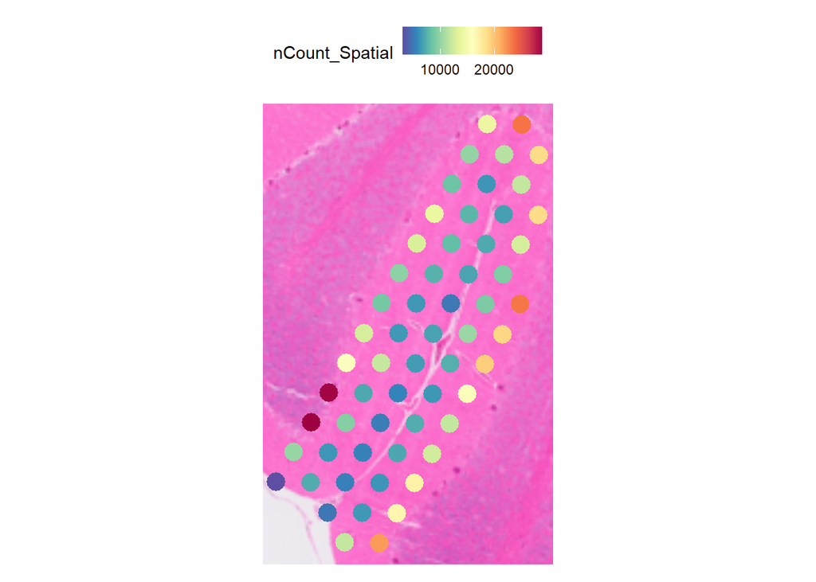

```r
MBrain.c1=subset(MBrain, idents="cortex1")
SpatialFeaturePlot(MBrain.c1, features = "nCount_Spatial", pt.size.factor = 20, image.scale="hires")
```

**Step 6:** Extract count matrix and reassemble new Seurat object for identity.1.

```r
MBrain.c1.dat=MBrain.c1[["Spatial"]]$counts
MBrain.c1=CreateSeuratObject(MBrain.c1.dat, assay="RNA")
Idents(MBrain.c1)="cortex1"
```

**Step 7:** Repeat steps 5&6 for all additional identities needed for data analysis

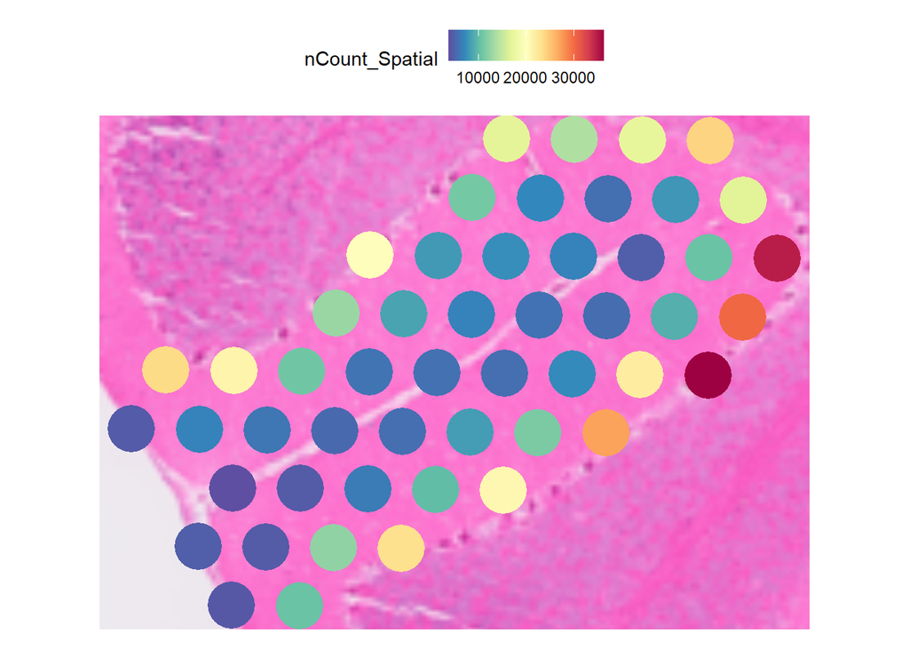

```r
MBrain.c2=subset(MBrain, idents="cortex2")
SpatialFeaturePlot(MBrain.c2, features = "nCount_Spatial", pt.size.factor = 20, image.scale="hires")
```

```r
MBrain.c2.dat=MBrain.c2[["Spatial"]]$counts
MBrain.c2=CreateSeuratObject(MBrain.c2.dat, assay = "RNA")
Idents(MBrain.c2)="cortex2"
```

**Step 8:** Merge all newly created Seurat objects into a single one and perform DGE analysis.

```r
MBrain.c1c2=JoinLayers(merge(MBrain.c1, y=MBrain.c2))
DGE.spatial=DGE.2samples(MBrain.c1c2, ident.1 = "cortex1", ident.2 = "cortex2")
```

```r
head(DGE.spatial)
```

```
##               log2FC    p.value Counts/Cell.1 Counts/Cell.2 N.+_cells.1
## Lypla1   0.576651227 0.08869608     0.7833333     0.5882353          32
## Tcea1   -0.120175621 0.73411361     1.0000000     1.1568627          32
## Atp6v1h -0.007936759 0.96571858     1.5833333     1.7254902          41
## Rb1cc1  -0.329682604 0.32708161     0.4833333     0.6666667          23
## St18    -0.753202923 0.06118155     0.5166667     0.9019608          18
## Pcmtd1  -0.455395736 0.02919357     1.2666667     1.8823529          41
##         N.+_cells.2 Counts.1 Counts.2  Sum_w^2.1  Sum_w^2.2 Chi2.p.value
## Lypla1           16       47       30 0.02145993 0.02453478   0.14295043
## Tcea1            27       60       59 0.01800590 0.02336077   0.79168202
## Atp6v1h          37       95       88 0.02145993 0.02917491   1.00000000
## Rb1cc1           26       29       34 0.02040498 0.02917491   0.40649331
## St18             26       31       46 0.02000837 0.02421093   0.05035849
## Pcmtd1           39       76       96 0.02145993 0.02917491   0.04678704
```

This sequence of steps is a bit clumsy. It is not really necessary to reassemble a new Seurat object. After assigning identities, verifying them, and renaming the assay to “RNA” we could use the original object for the DGE analysis.

```r
MBrain=RenameAssays(MBrain, Spatial="RNA")
DGE.spatial=DGE.2samples(MBrain, ident.1 = "cortex1", ident.2 = "cortex2")
```

```r
head(DGE.spatial)
```

```
##               log2FC    p.value Counts/Cell.1 Counts/Cell.2 N.+_cells.1
## Lypla1   0.576651227 0.08869608     0.7833333     0.5882353          32
## Tcea1   -0.120175621 0.73411361     1.0000000     1.1568627          32
## Atp6v1h -0.007936759 0.96571858     1.5833333     1.7254902          41
## Rb1cc1  -0.329682604 0.32708161     0.4833333     0.6666667          23
## St18    -0.753202923 0.06118155     0.5166667     0.9019608          18
## Pcmtd1  -0.455395736 0.02919357     1.2666667     1.8823529          41
##         N.+_cells.2 Counts.1 Counts.2  Sum_w^2.1  Sum_w^2.2 Chi2.p.value
## Lypla1           16       47       30 0.02145993 0.02453478   0.14295043
## Tcea1            27       60       59 0.01800590 0.02336077   0.79168202
## Atp6v1h          37       95       88 0.02145993 0.02917491   1.00000000
## Rb1cc1           26       29       34 0.02040498 0.02917491   0.40649331
## St18             26       31       46 0.02000837 0.02421093   0.05035849
## Pcmtd1           39       76       96 0.02145993 0.02917491   0.04678704
```

However, the reassembled Seurat object is much smaller than the original one, dramatically speeding up analysis of very large datasets. Being a creature of habit, I rarely use the latter shortcut.

**3.1.2: Interpretation of Visium DGE results**

Please note a large number of positive DGE findings from two similar areas of E18 mouse brain cortex in DGE.spatial, exceeding the number of false positive findings expected by chance due to multiple comparisons (see Chapter 4). In my experience, this is normal for Visium and doesn’t mean much. (a) Because the bins are fairly large, some of them collect RNA from brain areas adjacent to cortex, and the fraction of such RNA may be different in the two selected areas. (b) Each bin collects RNA from multiple cells, resulting in multiple cell types being present within each identity. Because the bins do not fully cover the area, the mix of cell types within the bins may be different in the two identities even if there is no difference between the cell composition in the two tissue areas. (c) There may be a difference in the cell composition even in anatomically similar tissue areas. It is important to be at least aware of these Visium assay features/limitations.

#### Section 3.2. High resolution assays (VisiumHD)

**3.2.1: LoadHD8um(), CropHD(), and GeneMap() functions for reducing the size and faster processing of Seurat’s objects containing VisiumHD data**

Seurat’s data import and object manipulation functions we used above for Visium can be used with VisiumHD data as well. In my experience, however, they produce objects that occupy too much memory, slow down processing, and become impossible to work with when results of multiple experiments must be combined together. To resolve these problems, I recommend functions included in the VisiumHD_functions_Seurat5.4+.R file available for download at https://github.com/sergeyleikin/sc-sp-RNASeq. Theese functions are also included in the tutorial dataset VisiumHD.zip available at https://www.synapse.org/Synapse:syn66520062/files/. They are compatible with the latest versions of Seurat (starting from v5.4.0) and SeuratObject (starting from v5.3.0). Because of a change in the coordinate system used by Seurat for Visium objects (x -> y and y -> x), these functions are not compatible with earlier Seurat versions. We do provide VisiumHD_functions.R file with the same functions for Seurat versions 5.0 to 5.3 and SeuratObject versions from 5.0 to 5.2. However, I strongly recommend updating Seurat and SeuratObject to the latest versions before working with VisiumHD data.

**Loading VisiumHD data with LoadHD8um()**

To use this tutorial for VisiumHD, download VisiumHD.zip from https://www.synapse.org/Synapse:syn66520062/files/ and unpack the archive into VisiumHD subfolder (should be default for VisiumHD.zip archive). Since this archive includes VisiumHD_functions_Seurat5.4+.R file, there is no need to download the latter separately.

Load VisiumHD_functions_Seurat5.4+.R and then load the provided Visium data (E18.5 mouse tibia sections) into Seurat object (replace C:/scRNASeq with the path to the unpacked VisiumHD folder)

```r
source("C:/scRNASeq/VisiumHD/VisiumHD_functions_Seurat5.4+.R")
Tib=LoadHD8um("C:/scRNASeq/VisiumHD", heGenes = c("Col1a1","Col2a1"))
```

In LoadHD8um() function, heGenes is a list of highly expressed genes useful for visualizing the data in R. Their relative counts are calculated and recorded in metadata as RC_Genename (e.g., RC_Col1a1 for Col1a1 and RC_Col2a1 for Col2a1).

This code loads the data for 8x8 um binned VisiumHD output. My testing of different data binning modes revealed that the actual spatial resolution of the assay is limited by probe diffusion rather than by 2x2 um binning of primers on VisiumHD slide surface. The real resolution is between 10 and 20 um, depending on the section thickness and tissue type. I therefore agree with the 8x8 um binning recommendation of 10X Genomics. This binning provides sufficient oversampling to prevent any spatial resolution loss while optimizing data analysis. Smaller bins reduce quality control efficiency and degrade statistical power of the analysis without any gain in spatial resolution. Larger bins may cause a spatial resolution loss.

**IMPORTANT:** In VisiumHD datasets, tissue images may be stored in **outs/spatial** directory, **outs/binned_outputs/square_008um/spatial** directory, or both. The LoadHD8um() function looks for full size tissue_hires_image.png file in **outs/binned_outputs/square_008um/spatial** directory. This file must be copied there from **outs/spatial** if the file is missing or has the size that appears too small (kilobytes instead of megabytes). The location of the full size file depends on SpaceRanger settings during data pre-processing.

**Quality control**,

```r
Tib[["percent.mt"]] <- PercentageFeatureSet(Tib, pattern = "^mt-")
Tib[["nonCol1"]]=colSums(Tib[["Spatial.008um"]]$counts)-Tib[["Spatial.008um"]]$counts["Col1a1",]-Tib[["Spatial.008um"]]$counts["Col1a2",]
Tib.QC=subset(Tib, subset = percent.mt >= 0.1 & percent.mt <= 5 & nonCol1 > 100 & nFeature_Spatial.008um >20 & RC_Col2a1>500)
```

In general, my experience suggests that the QC criteria must be optimized for every experiment to be consistent with the observed UMI counts per bin.

**Sample cropping with CropHD() and validation with GeneMap()**

The next step after is the selection of cell groups for DGE analysis and removing all unneeded data and image regions to reduce memory utilization (cropping). The selection of cell groups based on their spatial localization is performed in Loupe Browser. Download the E18_tibia.cloupe file from https://www.synapse.org/Synapse:syn66520062/files/ and open it in 10X Genomics LoupeBrowser software. In the Clusters tab, you can find preselected “Top”, “Mid”, and “Bot” regions. These are proliferative chondrocyte regions of proximal growth plates in 3 sections from the same E18.5 mouse tibia. After the preselection, barcodes of bins within these regions were exported from Loupe Browser into Top.csv, Mid.csv, and Bot.csv files included in the VisiumHD.zip archive (see Loupe Browser instructions for exporting such files). Based on these files we can crop the data and images using the CropHD(object,…) function. This function has a mandatory **barcodes** parameter and optional **padding** (default: padding=0.05), **xoffset** (default: xoffset=0), **yoffset** (default: yoffset=0), and **image.name** (default: image.name=“crop”) parameters. The value of **barcodes** identifies the file containing the selection barcodes **without** the .csv extension (e.g., “C:/scRNASeq/VisiumHD/Top” identifies Top.csv file in the C:/scRNASeq/VisiumHD folder, which contains the barcodes for the “Top” region). The value of **padding** specifies the size of the cropped image. The default setting adds 5% padding outside the rectangle containing all data. When the data is at the border of the VisiumHD slide, it may be necessary to set smaller or even zero padding to avoid CropHD() returning an error. Nonzero **xoffset** and **yoffset** settings allow correction of small misalignments between the high resolution image and data caused by imperfect fiducial point alignment during assay processing. This misalignment does not affect data analysis, but its correction may be beneficial for visualization. The **image.name** value allows assignment of user-defined name to the cropped tissue image, if desired.

```r
Tib.top=CropHD(Tib.QC, barcodes="C:/scRNASeq/VisiumHD/Top", xoffset = 0, yoffset = 0)
```

```
## Warning: Not validating FOV objects
## Not validating FOV objects
## Not validating FOV objects
## Not validating FOV objects
## Not validating FOV objects
## Not validating FOV objects
```

```
## Warning: Not validating Seurat objects
```

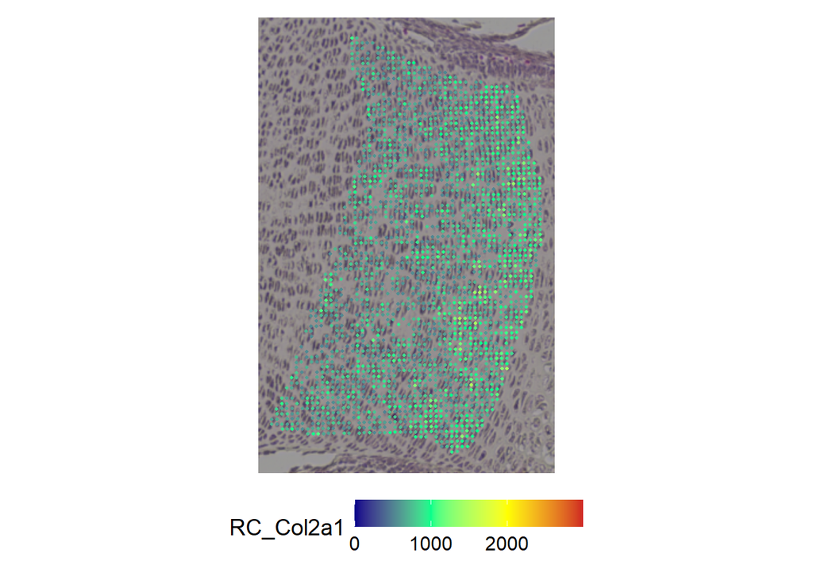

```r
GeneMap(Tib.top, map.features="RC_Col2a1", map.limits= c(0, 3000), pt.size=1.5, map.breaks = c(0,1000,2000))
```

Note that the CropHD() function in the code above produced multiple “Not validating…” warnings because of limitations in Seurat object design for VisiumHD experiments. The incompatibility of the cropped objects with the SeuratObject design for VisiumHD objects poses no problems for merging, accessing, or analyzing data using functions we recommend and describe below. The “Not validating…” warnings that appear during these operations can be ignored. However, we have not tested the compatibility with more complex object operations in Seurat. Before using additional Seurat functions, I recommend testing these functions by manually validating individual samples as described below.

After confirming successful cropping of the Top region, the same steps can be repeated for Mid and Bot regions.

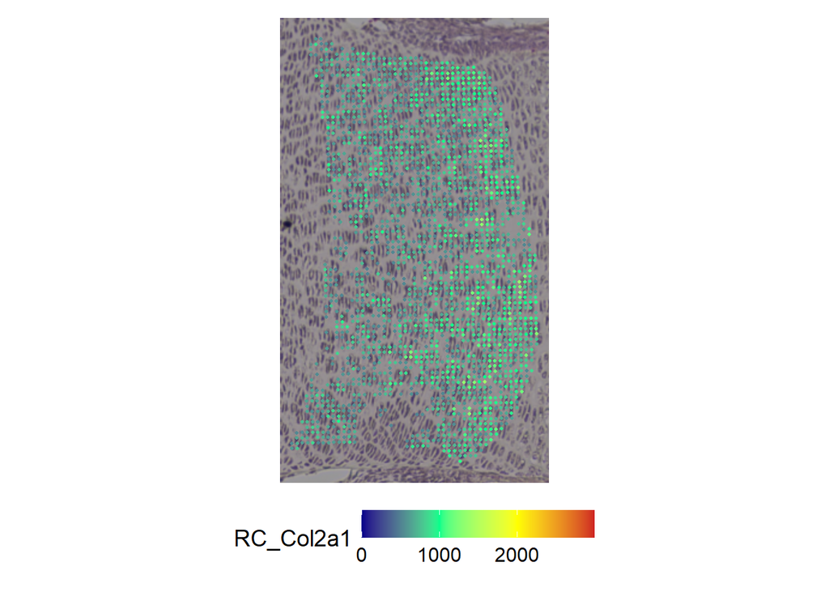

```r
Tib.mid=CropHD(Tib.QC, barcodes="C:/scRNASeq/VisiumHD/Mid", xoffset = 0, yoffset = 0)
GeneMap(Tib.mid, map.features="RC_Col2a1", map.limits= c(0, 3000), pt.size=1.5, map.breaks = c(0,1000,2000))
```

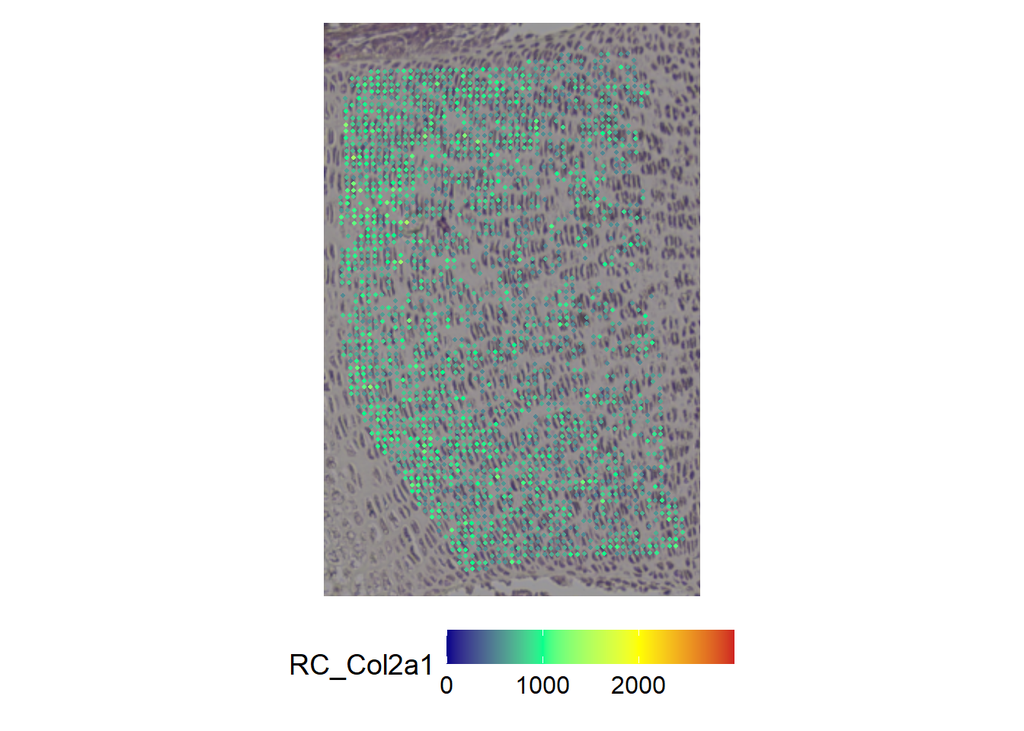

```r
Tib.bot=CropHD(Tib.QC, barcodes="C:/scRNASeq/VisiumHD/Bot", xoffset = 0, yoffset = 0)
GeneMap(Tib.bot, map.features="RC_Col2a1", map.limits= c(0, 3000), pt.size=1.5, map.breaks = c(0,1000,2000))
```

We then assemble a Seurat object that contains the cropped data and images and save it in case we might need it in the future.

```r
Idents(Tib.top)="Top"
Idents(Tib.mid)="Mid"
Idents(Tib.bot)="Bot"
Tib.crop.QC=JoinLayers(merge(Tib.top, y=c(Tib.mid,Tib.bot)))
saveRDS(Tib.crop.QC,"C:/scRNASeq/VisiumHD/Tib.crop.QC.rds")
print(paste0("Tib.QC object size ",format(object.size(Tib.QC), units = "MB"),"; Tib.crop.QC object size ",format(object.size(Tib.crop.QC), units = "MB")))
```

```
## [1] "Tib.QC object size 973.6 Mb; Tib.crop.QC object size 37.9 Mb"
```

Please note the dramatic reduction in the object size after cropping and removing all unneeded data and image regions. This is essential for assembling results of multiple experiments into a single Surat object.

**Assembly of Seurat object for DGE analysis**

Next, we reassemble a Seurat object that contains just the data for DGE analysis, as we described above for scRNASeq.

```r
Tib.top.dat=Tib.top[["Spatial.008um"]]$counts
Tib.top.s=CreateSeuratObject(Tib.top.dat, assay = "RNA")
Idents(Tib.top.s)="Top"
Tib.mid.dat=Tib.mid[["Spatial.008um"]]$counts
Tib.mid.s=CreateSeuratObject(Tib.mid.dat, assay = "RNA")
Idents(Tib.mid.s)="Mid"
Tib.bot.dat=Tib.bot[["Spatial.008um"]]$counts
Tib.bot.s=CreateSeuratObject(Tib.bot.dat, assay = "RNA")
Idents(Tib.bot.s)="Bot"
E18tib.GP=JoinLayers(merge(Tib.top.s, y=c(Tib.mid.s,Tib.bot.s)))
saveRDS(E18tib.GP,"C:/scRNASeq/VisiumHD/E18tib.GP.rds")
print(paste0("E18tib.GP ",format(object.size(E18tib.GP), units = "MB")))
```

[output not shown]

Because the further reduction in the object size is not very large, we could just change the assay name from “Spatial.008um” to “RNA” and then proceed directly to DGE analysis. However, in much larger experiments, reassembly of objects that contain only counts may significantly increase the analysis speed.

**3.2.2: DGE analysis**

High resolution spRNASeq with contiguous bins such as VisiumHD resolves some of the low resolution assay issues discussed above, but it has shortcomings as well. Most importantly, VisiumHD and similar assays do not resolve individual cells, even when their nominal spatial resolution is smaller than the cell size (2 um in VisiumHD). Diffusion of RNA probes and layering of cells on top of each other within tissue sections cause intermixing between RNA probes from different cells within each spatial bin, no matter how small the bins may be (see more detailed discussion in the Cell Rep. Methods manuscript). As a result, counts in adjacent bins are not independent from each other. VisiumHD bins do not represent independent transcript clusters, unlike cells in scRNASeq or bins in Visium. There are multiple ways to account for this feature of high-resolution assays, some of which are briefly discussed in the Cell Rep. Methods manuscript. The simplest approach is based on analysis of aggregate counts, which corresponds to the icc=0 setting (see Cell Rep. Methods manuscript).

Aside from the requirement of icc=0, the default 2-sample and multiple sample analyses of VisiumHD data can be performed similar to the DGE analysis of scRNASeq data, e.g.,

```r
DGE.top.mid=DGE.2samples(E18tib.GP, ident.1="Top", ident.2 = "Mid", icc=0)
```

```r
head(DGE.top.mid)
```

```
##               log2FC   p.value Counts/Cell.1 Counts/Cell.2 N.+_cells.1
## Lypla1  -0.006940908 0.9855575    0.01339286    0.01319510          30
## Tcea1   -0.012500433 0.9495523    0.04955357    0.04901037         110
## Atp6v1h  0.070827950 0.6861833    0.06562500    0.06126296         139
## Rb1cc1  -0.241406161 0.3903157    0.02276786    0.02639020          50
## Pcmtd1  -0.070852672 0.8254784    0.01830357    0.01885014          41
## Mybl1   -0.013367177 0.9711616    0.01428571    0.01413761          31
##         N.+_cells.2 Counts.1 Counts.2    Sum_w^2.1    Sum_w^2.2 Chi2.p.value
## Lypla1           27       30       28 0.0005024094 0.0005452936    1.0000000
## Tcea1           100      111      104 0.0005024094 0.0005452936    1.0000000
## Atp6v1h         124      147      130 0.0005024094 0.0005452936    0.7280565
## Rb1cc1           55       51       56 0.0005024094 0.0005452936    0.4420242
## Pcmtd1           39       41       40 0.0005024094 0.0005452936    0.9125509
## Mybl1            30       32       30 0.0005024094 0.0005452936    1.0000000
```

For VisiumHD, I do not recommend reducing min.cells and min.count settings below default values. Instead, if desired, they may be increased to improve the analysis accuracy. In my experience, VisiumHD data are more “noisy” than scRNASeq data and therefore require more counts for the same statistical accuracy.

### **Chapter 4. Multiple comparison corrections**

Our DGE analysis functions do not calculate p-values adjusted/corrected for multiple comparison (MC) in scRNASeq or spRNASeq because such adjustments/corrections depend on questions being addressed by the study. Unfortunatlely, my observations suggest that MC adjustments are often applied and/or interpreted incorrectly. While full discussion of underlying problems is beyond the scope of this tutorial, I nevertheless feel compelled to provide several examples to help readers of this tutorial with avoiding a very common mistake of “throwing the baby out with the bath water” when using MC adjustments.

Before we proceed, it is important to recall the exact meaning of unadjusted and MC-adjusted p-values.

**The unadjusted p-value for any specific gene is the probability of its measured log2FC value in the absence of its differential expression.** Mathematically, it is the probability of the measured log2FC when the underlying true population log2FC=0 (null hypohtesis). When sampling of different genes is independent – which is true in modern scRNASeq and spRNASeq assays – this probability is independent from all other genes and their number. The false positive probability is the unadjusted p-value.

**Bonferroni-adjusted p-value for a gene (more properly referred to as the** **family-wise error rate FWER) is 1 or the estimated number of false discoveries with the given p-value among all analyzed genes, whichever is smaller.** This is the mathematical definition for the Bonferroni adjustment formula FWER=min(1,N*p), where N is the number of analyzed genes and p is the p-value.

**Benjamini-Hochberg adjusted p-value for a gene (more properly referred to as the false discovery rate, FDR) is the estimated fraction of false positive discoveries among all analyzed genes with the same or lower unadjusted p-values.** This is the mathematical definition for the Benjamini-Hochberg FDR formula, which is a bit cumbersome and not provided here.

#### **Section 4.1. Bonferroni adjustment**

This is the default p-value adjustment in Seurat, which may cause complete misinterpretation of scRNASeq results. To understand why, consider a simple thought experiment.

An scRNASeq experiment is conducted with enough samples per genotype and enough cells per sample for very reliable statistical testing. The testing of N=10,000 moderate and high expression genes (the only ones of interest for the study) reveals 200 genes with highly significant unadjusted p-values p between 0.00001 and 0.0001 as well as multiple genes with larger p. The Bonferroni-adjusted p-values for the 200 highly significant genes (N*p) are between 0.1 and 1. The Bonferroni-adjusted p-values for all other genes are equal to 1. If the Bonferroni adjusted p-values were used to reject DGE findings as false positive ones, it would be a serious mistake. Indeed, N*p is the expected number of false positive findings with unadjusted p-value p. Therefore, the number of expected false positive findings with p-values between 0.00001 and 0.0001 among 10,000 genes is less than 1. This means that among the 200 genes with these p-values no more than one is expected to be false positive. While we do not know which one may be the false positive, rejecting all 200 is rather unwise.

As illustrated by this thought experiment, the purpose of the Bonferroni adjustment is to ensure zero false positive rate among the findings. Such zero false positive rate requirement might make sense for FDA approval of a treatment with dangerous side effects. However, I am not aware of any scRNASeq studies, for which such a requirement would be reasonable or useful.

#### **Section 4.2. Benjamini-Hochberg FDR**

**4.2.1: Global FDR**

Most commonly, the Benjamini-Hochberg FDR is calculated for all genes examined in a study. This approach can be combined with our DGE analysis functions by starting from the unadjusted results:

```r
DGE.results=DGE.2samples(Neuron.QC, ident.1 = "glutcells", ident.2 = "GABAcells", min.pct = 0.01 )
```

and calculating the FDR by using the p.adjust() function of base R

```r
DGE.results[["FDR"]]=p.adjust(DGE.results$p.value, method = "BH")
head(DGE.results)
```

```
##              log2FC      p.value Counts/Cell.1 Counts/Cell.2 N.+_cells.1
## Xkr4    -1.72746379 1.508410e-21     0.2910102     0.3915828         253
## Gm19938 -1.45819929 3.945424e-38     0.7284523     0.8508692         468
## Mrpl15   0.02186500 6.484253e-01     2.7849861     1.2195791         948
## Lypla1  -0.29875939 3.103853e-02     0.3595922     0.2003660         286
## Tcea1   -0.07754282 1.385491e-01     2.5329008     1.1857274         908
## Rgs20   -1.19603284 6.861898e-06     0.1158480     0.1189387          75
##         N.+_cells.2 Counts.1 Counts.2    Sum_w^2.1    Sum_w^2.2 Chi2.p.value
## Xkr4            273      314      428 0.0010917854 0.0009825243 2.985763e-55
## Gm19938         486      786      930 0.0010125781 0.0009997311 2.160678e-95
## Mrpl15          686     3005     1333 0.0011284367 0.0013078973 6.842078e-01
## Lypla1          166      388      219 0.0010613339 0.0012033431 8.107716e-03
## Tcea1           657     2733     1296 0.0010691492 0.0012339251 1.214113e-01
## Rgs20            91      125      130 0.0009651356 0.0011083073 9.063239e-12
##                  FDR
## Xkr4    2.191641e-20
## Gm19938 1.155496e-36
## Mrpl15  7.162674e-01
## Lypla1  5.407834e-02
## Tcea1   1.996032e-01
## Rgs20   2.557937e-05
```

The last column in this DGE.results dataframe reports the calculated FDR values. Usually, the findings are considered statistically significant when p<0.05 and FDR < 0.1. In our example

```r
DGE.results.FDR01 = DGE.results[DGE.results$FDR<0.1,]
DGE.results.FDR01 <- DGE.results.FDR01[order(-DGE.results.FDR01$p.value), ]
head(DGE.results.FDR01)
```

```
##               log2FC    p.value Counts/Cell.1 Counts/Cell.2 N.+_cells.1
## Krcc1     -0.2735424 0.06238840    0.35588508    0.20494053         266
## Bloc1s6os -0.8036745 0.06236954    0.02873031    0.02287283          27
## Fuca2     -0.3989954 0.06236021    0.15384615    0.08600183         137
## Sumf2      0.2612267 0.06232349    0.35217794    0.12991766         295
## Gm10941    0.8308328 0.06223361    0.04077850    0.01006404          39
## Ubxn7     -0.1650199 0.06219567    0.84615385    0.42726441         576
##           N.+_cells.2 Counts.1 Counts.2   Sum_w^2.1   Sum_w^2.2 Chi2.p.value
## Krcc1             154      384      224 0.001037013 0.001137699  0.002239231
## Bloc1s6os          25       31       25 0.001052109 0.001339613  0.039553189
## Fuca2              84      166       94 0.001070221 0.001170189  0.085343903
## Sumf2             131      380      142 0.001086578 0.001339613  0.065675363
## Gm10941            11       44       11 0.001079917 0.001339613  0.104836603
## Ubxn7             338      913      467 0.001061470 0.001264242  0.025650953
##                  FDR
## Krcc1     0.09994079
## Bloc1s6os 0.09992284
## Fuca2     0.09992014
## Sumf2     0.09987357
## Gm10941   0.09974177
## Ubxn7     0.09969320
```

```r
DGE.top.mid[["FDR"]]=p.adjust(DGE.top.mid$p.value, method = "BH")
DGE.top.mid.FDR01=DGE.top.mid[DGE.top.mid$FDR<0.1,]
DGE.top.mid.FDR01 <- DGE.top.mid.FDR01[order(-DGE.top.mid.FDR01$p.value), ]
knitr::kable(DGE.top.mid.FDR01)
```

|  | log2FC | p.value | Counts/Cell.1 | Counts/Cell.2 | N.+_cells.1 | N.+_cells.2 | Counts.1 | Counts.2 | Sum_w^2.1 | Sum_w^2.2 | Chi2.p.value | FDR |
| --- | --- | --- | --- | --- | --- | --- | --- | --- | --- | --- | --- | --- |
| Marcks | -1.1792329 | 0.0001974 | 0.0129464 | 0.0287465 | 29 | 61 | 29 | 61 | 0.0005024 | 0.0005453 | 0.0002944 | 0.0717291 |
| Dmp1 | -3.6914391 | 0.0001508 | 0.0013393 | 0.0169651 | 3 | 25 | 3 | 36 | 0.0005024 | 0.0005453 | 0.0000001 | 0.0580423 |
| Arhgap39 | -2.0606729 | 0.0001191 | 0.0035714 | 0.0146089 | 8 | 31 | 8 | 31 | 0.0005024 | 0.0005453 | 0.0001728 | 0.0486857 |
| St7l | -1.1939394 | 0.0000875 | 0.0142857 | 0.0320452 | 32 | 67 | 32 | 68 | 0.0005024 | 0.0005453 | 0.0001081 | 0.0381611 |
| Timp2 | -0.5858289 | 0.0000808 | 0.0758929 | 0.1116871 | 164 | 212 | 170 | 237 | 0.0005024 | 0.0005453 | 0.0000585 | 0.0377656 |
| Mylpf | -0.8805952 | 0.0000620 | 0.0308036 | 0.0556079 | 69 | 113 | 69 | 118 | 0.0005024 | 0.0005453 | 0.0000588 | 0.0311854 |
| Serpine2 | -1.8069163 | 0.0000210 | 0.0089286 | 0.0306315 | 20 | 52 | 20 | 65 | 0.0005024 | 0.0005453 | 0.0000003 | 0.0114664 |
| Exosc4 | 1.1435017 | 0.0000183 | 0.0392857 | 0.0174364 | 88 | 37 | 88 | 37 | 0.0005024 | 0.0005453 | 0.0000485 | 0.0108746 |
| Mmp13 | -3.3159299 | 0.0000069 | 0.0035714 | 0.0348728 | 8 | 43 | 8 | 74 | 0.0005024 | 0.0005453 | 0.0000000 | 0.0044966 |
| Acan | 0.0946172 | 0.0000067 | 6.4986607 | 5.9674835 | 2207 | 2081 | 14557 | 12663 | 0.0005024 | 0.0005453 | 0.0000001 | 0.0044966 |
| Tnc | -1.6553698 | 0.0000042 | 0.0120536 | 0.0372290 | 27 | 64 | 27 | 79 | 0.0005024 | 0.0005453 | 0.0000001 | 0.0034132 |
| Tpm2 | -1.3794951 | 0.0000007 | 0.0160714 | 0.0409991 | 36 | 86 | 36 | 87 | 0.0005024 | 0.0005453 | 0.0000009 | 0.0006079 |
| Ibsp | -1.6024341 | 0.0000003 | 0.0174107 | 0.0518379 | 39 | 88 | 39 | 110 | 0.0005024 | 0.0005453 | 0.0000000 | 0.0003364 |
| Matn1 | 0.1140349 | 0.0000000 | 6.9008929 | 6.2521206 | 2219 | 2089 | 15458 | 13267 | 0.0005024 | 0.0005453 | 0.0000000 | 0.0000394 |
| Col1a2 | -0.5055296 | 0.0000000 | 0.7495536 | 1.0433553 | 1136 | 1153 | 1679 | 2214 | 0.0005024 | 0.0005453 | 0.0000000 | 0.0000394 |
| Spp1 | -3.2001357 | 0.0000000 | 0.0183036 | 0.1649387 | 41 | 141 | 41 | 350 | 0.0005024 | 0.0005453 | 0.0000000 | 0.0000249 |
| Acta1 | -1.0420279 | 0.0000000 | 0.0459821 | 0.0928369 | 99 | 186 | 103 | 197 | 0.0005024 | 0.0005453 | 0.0000000 | 0.0000116 |
| Col1a1 | -1.1765089 | 0.0000000 | 0.6013393 | 1.3327050 | 946 | 1124 | 1347 | 2828 | 0.0005024 | 0.0005453 | 0.0000000 | 0.0000008 |

Here, the FDR < 0.1 requirement causes rejection of all findings with p>0.000197. However, there are 12 genes with p < 0.001 and FDR between 0.1 and 0.2, of which 2 or fewer are expected to be false positive findings (as indicated by the calculated FDR). By rejecting all these genes, one may easily throw out the proverbial baby with the bath water.

```r
DGE.top.mid.FDR01.02=DGE.top.mid[DGE.top.mid$FDR<0.2&DGE.top.mid$FDR>0.1,]
DGE.top.mid.FDR01.02 <- DGE.top.mid.FDR01.02[order(-DGE.top.mid.FDR01.02$p.value), ]
knitr::kable(DGE.top.mid.FDR01.02)
```

|  | log2FC | p.value | Counts/Cell.1 | Counts/Cell.2 | N.+_cells.1 | N.+_cells.2 | Counts.1 | Counts.2 | Sum_w^2.1 | Sum_w^2.2 | Chi2.p.value | FDR |
| --- | --- | --- | --- | --- | --- | --- | --- | --- | --- | --- | --- | --- |
| Snu13 | 0.5018364 | 0.0008417 | 0.0973214 | 0.0673893 | 213 | 138 | 218 | 143 | 0.0005024 | 0.0005453 | 0.0013918 | 0.1835520 |
| Map4 | -0.4335480 | 0.0007911 | 0.1000000 | 0.1324222 | 217 | 260 | 224 | 281 | 0.0005024 | 0.0005453 | 0.0008890 | 0.1784599 |
| Nme2 | 0.8624965 | 0.0006610 | 0.0410714 | 0.0221489 | 89 | 47 | 92 | 47 | 0.0005024 | 0.0005453 | 0.0009685 | 0.1544283 |
| Col9a3 | 0.0485687 | 0.0006426 | 11.9388393 | 11.3185674 | 2235 | 2116 | 26743 | 24018 | 0.0005024 | 0.0005453 | 0.0001305 | 0.1544283 |
| Cuta | 1.0999743 | 0.0006423 | 0.0267857 | 0.0122526 | 60 | 26 | 60 | 26 | 0.0005024 | 0.0005453 | 0.0012879 | 0.1544283 |
| Tet3 | 1.0267899 | 0.0005889 | 0.0303571 | 0.0146089 | 68 | 31 | 68 | 31 | 0.0005024 | 0.0005453 | 0.0011403 | 0.1541104 |
| Nptn | 0.7415203 | 0.0005062 | 0.0562500 | 0.0329877 | 122 | 67 | 126 | 70 | 0.0005024 | 0.0005453 | 0.0006386 | 0.1379855 |
| Psmc2 | 0.6478711 | 0.0004371 | 0.0745536 | 0.0466541 | 155 | 96 | 167 | 99 | 0.0005024 | 0.0005453 | 0.0004497 | 0.1243322 |
| Cacybp | 0.8935234 | 0.0004317 | 0.0410714 | 0.0216777 | 89 | 46 | 92 | 46 | 0.0005024 | 0.0005453 | 0.0006744 | 0.1243322 |
| Postn | -1.3391373 | 0.0004158 | 0.0089286 | 0.0221489 | 20 | 46 | 20 | 47 | 0.0005024 | 0.0005453 | 0.0005000 | 0.1243322 |
| Fkbp15 | -1.5470492 | 0.0003770 | 0.0062500 | 0.0179076 | 14 | 38 | 14 | 38 | 0.0005024 | 0.0005453 | 0.0005444 | 0.1233245 |
| Timm17b | 0.6419847 | 0.0003207 | 0.0750000 | 0.0471254 | 164 | 96 | 168 | 100 | 0.0005024 | 0.0005453 | 0.0004805 | 0.1104378 |

For instance, if are interested just in the following specific set of extracellular matrix (ECM) genes:

```r
ecm.genes=c("Col1a1","Col1a2","Col2a1","Col9a1","Col9a2","Col9a3","Col10a1","Comp","Matn1","Matn3","Prelp","Dcn","Bgn","Acan")
```

We can calculate the FDR just for them:

```r
DGE.top.mid.ecm=DGE.top.mid[ecm.genes,]
DGE.top.mid.ecm[["FDR"]]=p.adjust(DGE.top.mid.ecm$p.value, method="BH")
DGE.top.mid.ecm <- DGE.top.mid.ecm[order(-DGE.top.mid.ecm$p.value), ]
knitr::kable(DGE.top.mid.ecm)
```

|  | log2FC | p.value | Counts/Cell.1 | Counts/Cell.2 | N.+_cells.1 | N.+_cells.2 | Counts.1 | Counts.2 | Sum_w^2.1 | Sum_w^2.2 | Chi2.p.value | FDR |
| --- | --- | --- | --- | --- | --- | --- | --- | --- | --- | --- | --- | --- |
| Bgn | -0.0150536 | 0.8310954 | 0.5089286 | 0.5042413 | 767 | 717 | 1140 | 1070 | 0.0005024 | 0.0005453 | 0.8227865 | 0.8310954 |
| Col9a2 | 0.0081412 | 0.6547869 | 7.2424107 | 7.0612630 | 2216 | 2102 | 16223 | 14984 | 0.0005024 | 0.0005453 | 0.6200459 | 0.7051551 |
| Col9a1 | -0.0194851 | 0.3976028 | 4.0129464 | 3.9882187 | 2143 | 2016 | 8989 | 8463 | 0.0005024 | 0.0005453 | 0.3747862 | 0.4638699 |
| Dcn | -0.2369786 | 0.1319526 | 0.0754464 | 0.0871819 | 156 | 175 | 169 | 185 | 0.0005024 | 0.0005453 | 0.1356038 | 0.1679397 |
| Comp | 0.0670498 | 0.0358463 | 3.4468750 | 3.2262017 | 2010 | 1858 | 7721 | 6846 | 0.0005024 | 0.0005453 | 0.0051024 | 0.0501849 |
| Col2a1 | 0.0244778 | 0.0202844 | 39.5325893 | 38.1098021 | 2240 | 2122 | 88553 | 80869 | 0.0005024 | 0.0005453 | 0.0002912 | 0.0315536 |
| Prelp | 0.1310496 | 0.0156122 | 0.7558036 | 0.6767201 | 1130 | 985 | 1693 | 1436 | 0.0005024 | 0.0005453 | 0.0118456 | 0.0273214 |
| Matn3 | 0.1124478 | 0.0050902 | 1.3602679 | 1.2337418 | 1573 | 1415 | 3047 | 2618 | 0.0005024 | 0.0005453 | 0.0035469 | 0.0101804 |
| Col10a1 | 0.5681231 | 0.0032091 | 0.1482143 | 0.0980207 | 201 | 155 | 332 | 208 | 0.0005024 | 0.0005453 | 0.0000090 | 0.0074879 |
| Col9a3 | 0.0485687 | 0.0006426 | 11.9388393 | 11.3185674 | 2235 | 2116 | 26743 | 24018 | 0.0005024 | 0.0005453 | 0.0001305 | 0.0017994 |
| Acan | 0.0946172 | 0.0000067 | 6.4986607 | 5.9674835 | 2207 | 2081 | 14557 | 12663 | 0.0005024 | 0.0005453 | 0.0000001 | 0.0000234 |
| Matn1 | 0.1140349 | 0.0000000 | 6.9008929 | 6.2521206 | 2219 | 2089 | 15458 | 13267 | 0.0005024 | 0.0005453 | 0.0000000 | 0.0000001 |
| Col1a2 | -0.5055296 | 0.0000000 | 0.7495536 | 1.0433553 | 1136 | 1153 | 1679 | 2214 | 0.0005024 | 0.0005453 | 0.0000000 | 0.0000001 |
| Col1a1 | -1.1765089 | 0.0000000 | 0.6013393 | 1.3327050 | 946 | 1124 | 1347 | 2828 | 0.0005024 | 0.0005453 | 0.0000000 | 0.0000000 |

This FDR analysis reveals Comp, Col2a1, Prelp, Matn3, Col10a1, Col9a3, Acan, Matn1, Col1a2, and Col1a1 to be likely true positive findings with only 1 expected false positive among them. The global FDR analysis identified only the last 4 of these genes. What if the other ones are more important and can change the study conclusions? At the very least, they are well worth exploring in additional experiments.

**4.2.2: Pathway-specific and biological-function-specific FDR**

In general, DGE analysis of scRNASeq and spRNASeq data is particularly useful for identifying up/down-regulated pathways, yet the global FDR calculation may be counterproductive for such analysis as illustrated by the last example. In my opinion, a better approach is to identify pathways and/or biological functions of interest for the study and then perform FDR analysis specifically for these pathways and/or functions like the one for ECM genes above. Ideally, the lists of genes for these pathways/functions to check should be compiled completely independently from the DGE analysis to avoid biasing the results.

Our last example, however, illustrates a less perfect yet viable approach that identifies pathways to check based on DGE findings. For instance,

```r
print(t(DGE.top.mid["Smad3",]))
```

```
##                      Smad3
## log2FC        8.935234e-01
## p.value       4.304017e-02
## Counts/Cell.1 1.339286e-02
## Counts/Cell.2 7.068803e-03
## N.+_cells.1   3.000000e+01
## N.+_cells.2   1.500000e+01
## Counts.1      3.000000e+01
## Counts.2      1.500000e+01
## Sum_w^2.1     5.024094e-04
## Sum_w^2.2     5.452936e-04
## Chi2.p.value  6.564590e-02
## FDR           7.004199e-01
```

the table above shows that Smad3 has log2FC=0.89 and unadjusted p.value=0.04. How likely is this to be a true positive finding? To get a better idea, we can use that Smad3 is a key gene involved in the TGFb pathway. Thus, we can compile a list of all other known (or relevant) TGFb pathway genes. As long as this list is compiled based on existing knowledge and is independent from the DGE analysis output, we can use it for FDR analysis. After downloading such list (TGFb.csv, https://github.com/sergeyleikin/sc-sp-RNASeq), we find

```r
tgfb=read.csv("C:/scRNASeq/TGFb.csv")$Symbol
tgfb.genes=intersect(rownames(DGE.top.mid),tgfb)
DGE.top.mid.tgfb=DGE.top.mid[tgfb.genes,]
DGE.top.mid.tgfb[["FDR"]]=p.adjust(DGE.top.mid.tgfb$p.value, method = "BH")
DGE.top.mid.tgfb.p05.FDR01=DGE.top.mid.tgfb[DGE.top.mid.tgfb$p.value<0.05&DGE.top.mid.tgfb$FDR<0.5,]
print(paste0("TGFb genes in the list: ", length(tgfb), "; TGFb genes examined:", length(tgfb.genes), "; p<0.05&FDR<0.5 genes: ", nrow(DGE.top.mid.tgfb.p05.FDR01)))
```

```
## [1] "TGFb genes in the list: 87; TGFb genes examined:39; p<0.05&FDR<0.5 genes: 0"
```

This analysis reveals no genes in the TGFb pathway with p<0.05 and pathway-specific FDR<0.5, suggesting that the pathway is not likely to be up- or down-regulated. The Smad3 finding is probably a false positive one.